# Risk Factor Analysis

## Outcome Variable

**Outcome Variable:** ever_co

## Predictor Variables

**Intervention Variable:** birthwt

**Adjustment Set:**

unadjusted

## Stratifying Variables

The analysis was stratified on these variable(s):

- agecat
- studyid
- country

## Data Summary

| agecat | studyid | country | birthwt | ever_co | n_cell | n |
| --- | --- | --- | --- | --- | --- | --- |
| 0-24 months | CMC-V-BCS-2002 | INDIA | Normal or high birthweight | 0 | 266 | 365 |
| 0-24 months | CMC-V-BCS-2002 | INDIA | Normal or high birthweight | 1 | 56 | 365 |
| 0-24 months | CMC-V-BCS-2002 | INDIA | Low birthweight | 0 | 16 | 365 |
| 0-24 months | CMC-V-BCS-2002 | INDIA | Low birthweight | 1 | 27 | 365 |
| 0-24 months | CMIN | BANGLADESH | Normal or high birthweight | 0 | 12 | 20 |
| 0-24 months | CMIN | BANGLADESH | Normal or high birthweight | 1 | 2 | 20 |
| 0-24 months | CMIN | BANGLADESH | Low birthweight | 0 | 4 | 20 |
| 0-24 months | CMIN | BANGLADESH | Low birthweight | 1 | 2 | 20 |
| 0-24 months | COHORTS | GUATEMALA | Normal or high birthweight | 0 | 763 | 929 |
| 0-24 months | COHORTS | GUATEMALA | Normal or high birthweight | 1 | 85 | 929 |
| 0-24 months | COHORTS | GUATEMALA | Low birthweight | 0 | 64 | 929 |
| 0-24 months | COHORTS | GUATEMALA | Low birthweight | 1 | 17 | 929 |
| 0-24 months | COHORTS | INDIA | Normal or high birthweight | 0 | 5088 | 6758 |
| 0-24 months | COHORTS | INDIA | Normal or high birthweight | 1 | 291 | 6758 |
| 0-24 months | COHORTS | INDIA | Low birthweight | 0 | 1059 | 6758 |
| 0-24 months | COHORTS | INDIA | Low birthweight | 1 | 320 | 6758 |
| 0-24 months | COHORTS | PHILIPPINES | Normal or high birthweight | 0 | 2283 | 3001 |
| 0-24 months | COHORTS | PHILIPPINES | Normal or high birthweight | 1 | 431 | 3001 |
| 0-24 months | COHORTS | PHILIPPINES | Low birthweight | 0 | 168 | 3001 |
| 0-24 months | COHORTS | PHILIPPINES | Low birthweight | 1 | 119 | 3001 |
| 0-24 months | CONTENT | PERU | Normal or high birthweight | 0 | 2 | 2 |
| 0-24 months | CONTENT | PERU | Normal or high birthweight | 1 | 0 | 2 |
| 0-24 months | CONTENT | PERU | Low birthweight | 0 | 0 | 2 |
| 0-24 months | CONTENT | PERU | Low birthweight | 1 | 0 | 2 |
| 0-24 months | EE | PAKISTAN | Normal or high birthweight | 0 | 154 | 378 |
| 0-24 months | EE | PAKISTAN | Normal or high birthweight | 1 | 91 | 378 |
| 0-24 months | EE | PAKISTAN | Low birthweight | 0 | 55 | 378 |
| 0-24 months | EE | PAKISTAN | Low birthweight | 1 | 78 | 378 |
| 0-24 months | GMS-Nepal | NEPAL | Normal or high birthweight | 0 | 374 | 685 |
| 0-24 months | GMS-Nepal | NEPAL | Normal or high birthweight | 1 | 103 | 685 |

[output cut: 294 more lines]

The following strata were considered:

- agecat: 0-24 months, studyid: CMC-V-BCS-2002, country: INDIA
- agecat: 0-24 months, studyid: CMIN, country: BANGLADESH
- agecat: 0-24 months, studyid: COHORTS, country: GUATEMALA
- agecat: 0-24 months, studyid: COHORTS, country: INDIA
- agecat: 0-24 months, studyid: COHORTS, country: PHILIPPINES
- agecat: 0-24 months, studyid: CONTENT, country: PERU
- agecat: 0-24 months, studyid: EE, country: PAKISTAN
- agecat: 0-24 months, studyid: GMS-Nepal, country: NEPAL
- agecat: 0-24 months, studyid: IRC, country: INDIA
- agecat: 0-24 months, studyid: JiVitA-3, country: BANGLADESH
- agecat: 0-24 months, studyid: JiVitA-4, country: BANGLADESH
- agecat: 0-24 months, studyid: Keneba, country: GAMBIA
- agecat: 0-24 months, studyid: MAL-ED, country: BANGLADESH
- agecat: 0-24 months, studyid: MAL-ED, country: BRAZIL
- agecat: 0-24 months, studyid: MAL-ED, country: INDIA
- agecat: 0-24 months, studyid: MAL-ED, country: NEPAL
- agecat: 0-24 months, studyid: MAL-ED, country: PERU
- agecat: 0-24 months, studyid: MAL-ED, country: SOUTH AFRICA
- agecat: 0-24 months, studyid: MAL-ED, country: TANZANIA, UNITED REPUBLIC OF
- agecat: 0-24 months, studyid: NIH-Birth, country: BANGLADESH
- agecat: 0-24 months, studyid: NIH-Crypto, country: BANGLADESH
- agecat: 0-24 months, studyid: PROBIT, country: BELARUS
- agecat: 0-24 months, studyid: PROVIDE, country: BANGLADESH
- agecat: 0-24 months, studyid: ResPak, country: PAKISTAN
- agecat: 0-24 months, studyid: SAS-CompFeed, country: INDIA
- agecat: 0-24 months, studyid: TanzaniaChild2, country: TANZANIA, UNITED REPUBLIC OF
- agecat: 0-24 months, studyid: ZVITAMBO, country: ZIMBABWE
- agecat: 0-6 months, studyid: CMC-V-BCS-2002, country: INDIA
- agecat: 0-6 months, studyid: CMIN, country: BANGLADESH
- agecat: 0-6 months, studyid: COHORTS, country: GUATEMALA
- agecat: 0-6 months, studyid: COHORTS, country: INDIA
- agecat: 0-6 months, studyid: COHORTS, country: PHILIPPINES
- agecat: 0-6 months, studyid: CONTENT, country: PERU
- agecat: 0-6 months, studyid: EE, country: PAKISTAN
- agecat: 0-6 months, studyid: GMS-Nepal, country: NEPAL
- agecat: 0-6 months, studyid: IRC, country: INDIA
- agecat: 0-6 months, studyid: JiVitA-3, country: BANGLADESH
- agecat: 0-6 months, studyid: JiVitA-4, country: BANGLADESH
- agecat: 0-6 months, studyid: Keneba, country: GAMBIA
- agecat: 0-6 months, studyid: MAL-ED, country: BANGLADESH
- agecat: 0-6 months, studyid: MAL-ED, country: BRAZIL
- agecat: 0-6 months, studyid: MAL-ED, country: INDIA
- agecat: 0-6 months, studyid: MAL-ED, country: NEPAL
- agecat: 0-6 months, studyid: MAL-ED, country: PERU
- agecat: 0-6 months, studyid: MAL-ED, country: SOUTH AFRICA
- agecat: 0-6 months, studyid: MAL-ED, country: TANZANIA, UNITED REPUBLIC OF
- agecat: 0-6 months, studyid: NIH-Birth, country: BANGLADESH
- agecat: 0-6 months, studyid: NIH-Crypto, country: BANGLADESH
- agecat: 0-6 months, studyid: PROBIT, country: BELARUS
- agecat: 0-6 months, studyid: PROVIDE, country: BANGLADESH
- agecat: 0-6 months, studyid: ResPak, country: PAKISTAN
- agecat: 0-6 months, studyid: SAS-CompFeed, country: INDIA
- agecat: 0-6 months, studyid: TanzaniaChild2, country: TANZANIA, UNITED REPUBLIC OF
- agecat: 0-6 months, studyid: ZVITAMBO, country: ZIMBABWE
- agecat: 6-24 months, studyid: CMC-V-BCS-2002, country: INDIA
- agecat: 6-24 months, studyid: CMIN, country: BANGLADESH
- agecat: 6-24 months, studyid: COHORTS, country: GUATEMALA
- agecat: 6-24 months, studyid: COHORTS, country: INDIA
- agecat: 6-24 months, studyid: COHORTS, country: PHILIPPINES
- agecat: 6-24 months, studyid: CONTENT, country: PERU
- agecat: 6-24 months, studyid: EE, country: PAKISTAN
- agecat: 6-24 months, studyid: GMS-Nepal, country: NEPAL
- agecat: 6-24 months, studyid: IRC, country: INDIA
- agecat: 6-24 months, studyid: JiVitA-3, country: BANGLADESH
- agecat: 6-24 months, studyid: JiVitA-4, country: BANGLADESH
- agecat: 6-24 months, studyid: Keneba, country: GAMBIA
- agecat: 6-24 months, studyid: MAL-ED, country: BANGLADESH
- agecat: 6-24 months, studyid: MAL-ED, country: BRAZIL
- agecat: 6-24 months, studyid: MAL-ED, country: INDIA
- agecat: 6-24 months, studyid: MAL-ED, country: NEPAL
- agecat: 6-24 months, studyid: MAL-ED, country: PERU
- agecat: 6-24 months, studyid: MAL-ED, country: SOUTH AFRICA
- agecat: 6-24 months, studyid: MAL-ED, country: TANZANIA, UNITED REPUBLIC OF
- agecat: 6-24 months, studyid: NIH-Birth, country: BANGLADESH
- agecat: 6-24 months, studyid: NIH-Crypto, country: BANGLADESH
- agecat: 6-24 months, studyid: PROBIT, country: BELARUS
- agecat: 6-24 months, studyid: PROVIDE, country: BANGLADESH
- agecat: 6-24 months, studyid: ResPak, country: PAKISTAN
- agecat: 6-24 months, studyid: SAS-CompFeed, country: INDIA
- agecat: 6-24 months, studyid: TanzaniaChild2, country: TANZANIA, UNITED REPUBLIC OF
- agecat: 6-24 months, studyid: ZVITAMBO, country: ZIMBABWE

### Dropped Strata

Some strata were dropped due to rare outcomes:

- agecat: 0-24 months, studyid: CMIN, country: BANGLADESH
- agecat: 0-24 months, studyid: CONTENT, country: PERU
- agecat: 0-24 months, studyid: MAL-ED, country: BRAZIL
- agecat: 0-24 months, studyid: MAL-ED, country: TANZANIA, UNITED REPUBLIC OF
- agecat: 0-24 months, studyid: PROBIT, country: BELARUS
- agecat: 0-24 months, studyid: ResPak, country: PAKISTAN
- agecat: 0-6 months, studyid: CMIN, country: BANGLADESH
- agecat: 0-6 months, studyid: COHORTS, country: GUATEMALA
- agecat: 0-6 months, studyid: CONTENT, country: PERU
- agecat: 0-6 months, studyid: MAL-ED, country: BANGLADESH
- agecat: 0-6 months, studyid: MAL-ED, country: BRAZIL
- agecat: 0-6 months, studyid: MAL-ED, country: NEPAL
- agecat: 0-6 months, studyid: MAL-ED, country: PERU
- agecat: 0-6 months, studyid: MAL-ED, country: SOUTH AFRICA
- agecat: 0-6 months, studyid: MAL-ED, country: TANZANIA, UNITED REPUBLIC OF
- agecat: 0-6 months, studyid: NIH-Crypto, country: BANGLADESH
- agecat: 0-6 months, studyid: PROBIT, country: BELARUS
- agecat: 0-6 months, studyid: ResPak, country: PAKISTAN
- agecat: 6-24 months, studyid: CMIN, country: BANGLADESH
- agecat: 6-24 months, studyid: CONTENT, country: PERU
- agecat: 6-24 months, studyid: MAL-ED, country: BRAZIL
- agecat: 6-24 months, studyid: MAL-ED, country: NEPAL
- agecat: 6-24 months, studyid: MAL-ED, country: PERU
- agecat: 6-24 months, studyid: MAL-ED, country: SOUTH AFRICA
- agecat: 6-24 months, studyid: MAL-ED, country: TANZANIA, UNITED REPUBLIC OF
- agecat: 6-24 months, studyid: PROBIT, country: BELARUS
- agecat: 6-24 months, studyid: ResPak, country: PAKISTAN

## Methods Detail

We’re interested in the causal parameters $E[Y_a]$ for all values of $a \in \mathcal{A}$. These parameters represent the mean outcome if, possibly contrary to fact, we intervened to set all units to have $A=a$. Under the randomization and positivity assumptions, these are identified by the statistical parameters $\psi_a=E_W[E_{Y|A,W}(Y|A=a,W)]$. In addition, we’re interested in the mean of $Y$, $E[Y]$ under no intervention (the observed mean). We will estimate these parameters by using SuperLearner to fit the relevant likelihood factors – $E_{Y|A,W}(Y|A=a,W)$ and $p(A=a|W)$, and then updating our likelihood fit using a joint TMLE.

For unadjusted analyses ($W=\{\}$), initial likelihoods were estimated using Lrnr_glm to estimate the simple $E(Y|A)$ and Lrnr_mean to estimate $p(A)$. For adjusted analyses, a small library containing Lrnr_glmnet, Lrnr_xgboost, and Lrnr_mean was used.

Having estimated these parameters, we will then use the delta method to estimate relative risks and attributable risks relative to a prespecified baseline level of $A$.

# Results Detail

## Results Plots

[figure not shown]

[figure not shown]

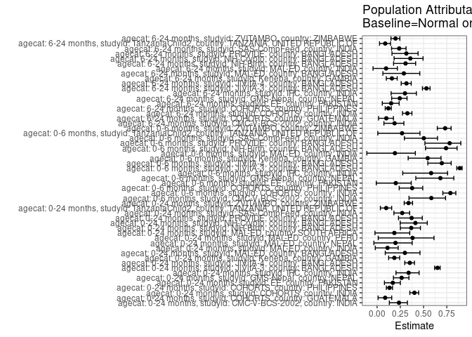

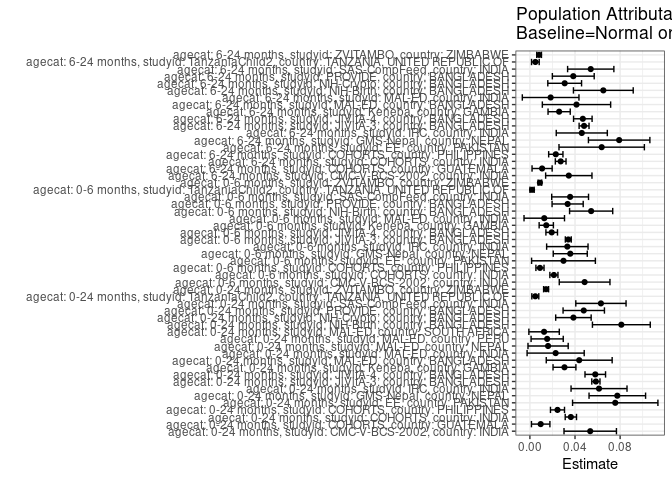

## Results Table

### Parameter: TSM

| agecat | studyid | country | intervention_level | baseline_level | estimate | ci_lower | ci_upper |
| --- | --- | --- | --- | --- | --- | --- | --- |
| 0-24 months | CMC-V-BCS-2002 | INDIA | Normal or high birthweight | NA | 0.1739130 | 0.1324563 | 0.2153698 |
| 0-24 months | CMC-V-BCS-2002 | INDIA | Low birthweight | NA | 0.6279070 | 0.4832355 | 0.7725785 |
| 0-24 months | COHORTS | GUATEMALA | Normal or high birthweight | NA | 0.1002358 | 0.0800122 | 0.1204595 |
| 0-24 months | COHORTS | GUATEMALA | Low birthweight | NA | 0.2098765 | 0.1211469 | 0.2986062 |
| 0-24 months | COHORTS | INDIA | Normal or high birthweight | NA | 0.0540993 | 0.0480536 | 0.0601450 |
| 0-24 months | COHORTS | INDIA | Low birthweight | NA | 0.2320522 | 0.2097701 | 0.2543343 |
| 0-24 months | COHORTS | PHILIPPINES | Normal or high birthweight | NA | 0.1588062 | 0.1450532 | 0.1725592 |
| 0-24 months | COHORTS | PHILIPPINES | Low birthweight | NA | 0.4146341 | 0.3576275 | 0.4716408 |
| 0-24 months | EE | PAKISTAN | Normal or high birthweight | NA | 0.3714286 | 0.3108449 | 0.4320122 |
| 0-24 months | EE | PAKISTAN | Low birthweight | NA | 0.5864662 | 0.5026603 | 0.6702720 |
| 0-24 months | GMS-Nepal | NEPAL | Normal or high birthweight | NA | 0.2159329 | 0.1789806 | 0.2528853 |
| 0-24 months | GMS-Nepal | NEPAL | Low birthweight | NA | 0.4711538 | 0.4032679 | 0.5390398 |
| 0-24 months | IRC | INDIA | Normal or high birthweight | NA | 0.1194030 | 0.0846366 | 0.1541694 |
| 0-24 months | IRC | INDIA | Low birthweight | NA | 0.4782609 | 0.3602503 | 0.5962714 |
| 0-24 months | JiVitA-3 | BANGLADESH | Normal or high birthweight | NA | 0.0315378 | 0.0283517 | 0.0347238 |
| 0-24 months | JiVitA-3 | BANGLADESH | Low birthweight | NA | 0.1703540 | 0.1623626 | 0.1783453 |
| 0-24 months | JiVitA-4 | BANGLADESH | Normal or high birthweight | NA | 0.1066386 | 0.0940702 | 0.1192071 |
| 0-24 months | JiVitA-4 | BANGLADESH | Low birthweight | NA | 0.3282443 | 0.2973961 | 0.3590924 |
| 0-24 months | Keneba | GAMBIA | Normal or high birthweight | NA | 0.1344985 | 0.1160588 | 0.1529382 |
| 0-24 months | Keneba | GAMBIA | Low birthweight | NA | 0.3468468 | 0.2842159 | 0.4094778 |
| 0-24 months | MAL-ED | BANGLADESH | Normal or high birthweight | NA | 0.1024390 | 0.0608506 | 0.1440275 |
| 0-24 months | MAL-ED | BANGLADESH | Low birthweight | NA | 0.3090909 | 0.1867259 | 0.4314559 |
| 0-24 months | MAL-ED | INDIA | Normal or high birthweight | NA | 0.1804878 | 0.1277313 | 0.2332443 |
| 0-24 months | MAL-ED | INDIA | Low birthweight | NA | 0.3333333 | 0.1790235 | 0.4876431 |
| 0-24 months | MAL-ED | NEPAL | Normal or high birthweight | NA | 0.0654206 | 0.0322204 | 0.0986207 |
| 0-24 months | MAL-ED | NEPAL | Low birthweight | NA | 0.2631579 | 0.0647309 | 0.4615849 |
| 0-24 months | MAL-ED | PERU | Normal or high birthweight | NA | 0.0248227 | 0.0066333 | 0.0430120 |
| 0-24 months | MAL-ED | PERU | Low birthweight | NA | 0.2941176 | 0.0771586 | 0.5110767 |
| 0-24 months | MAL-ED | SOUTH AFRICA | Normal or high birthweight | NA | 0.0551724 | 0.0288523 | 0.0814925 |
| 0-24 months | MAL-ED | SOUTH AFRICA | Low birthweight | NA | 0.2500000 | 0.0599205 | 0.4400795 |

[output cut: 78 more lines]

### Parameter: E(Y)

| agecat | studyid | country | intervention_level | baseline_level | estimate | ci_lower | ci_upper |
| --- | --- | --- | --- | --- | --- | --- | --- |
| 0-24 months | CMC-V-BCS-2002 | INDIA | NA | NA | 0.2273973 | 0.1843378 | 0.2704567 |
| 0-24 months | COHORTS | GUATEMALA | NA | NA | 0.1097955 | 0.0896809 | 0.1299101 |
| 0-24 months | COHORTS | INDIA | NA | NA | 0.0904114 | 0.0835737 | 0.0972490 |
| 0-24 months | COHORTS | PHILIPPINES | NA | NA | 0.1832722 | 0.1694278 | 0.1971167 |
| 0-24 months | EE | PAKISTAN | NA | NA | 0.4470899 | 0.3969017 | 0.4972782 |
| 0-24 months | GMS-Nepal | NEPAL | NA | NA | 0.2934307 | 0.2593074 | 0.3275539 |
| 0-24 months | IRC | INDIA | NA | NA | 0.1806931 | 0.1431275 | 0.2182586 |
| 0-24 months | JiVitA-3 | BANGLADESH | NA | NA | 0.0900373 | 0.0858293 | 0.0942453 |
| 0-24 months | JiVitA-4 | BANGLADESH | NA | NA | 0.1645963 | 0.1519758 | 0.1772167 |
| 0-24 months | Keneba | GAMBIA | NA | NA | 0.1651495 | 0.1465863 | 0.1837128 |
| 0-24 months | MAL-ED | BANGLADESH | NA | NA | 0.1461538 | 0.1031316 | 0.1891761 |
| 0-24 months | MAL-ED | INDIA | NA | NA | 0.2033195 | 0.1524012 | 0.2542378 |
| 0-24 months | MAL-ED | NEPAL | NA | NA | 0.0815451 | 0.0463297 | 0.1167604 |
| 0-24 months | MAL-ED | PERU | NA | NA | 0.0401338 | 0.0178494 | 0.0624181 |
| 0-24 months | MAL-ED | SOUTH AFRICA | NA | NA | 0.0677419 | 0.0397221 | 0.0957618 |
| 0-24 months | NIH-Birth | BANGLADESH | NA | NA | 0.2205638 | 0.1874426 | 0.2536851 |
| 0-24 months | NIH-Crypto | BANGLADESH | NA | NA | 0.0936675 | 0.0729118 | 0.1144233 |
| 0-24 months | PROVIDE | BANGLADESH | NA | NA | 0.1285714 | 0.1037574 | 0.1533855 |
| 0-24 months | SAS-CompFeed | INDIA | NA | NA | 0.2328676 | 0.1923832 | 0.2733520 |
| 0-24 months | TanzaniaChild2 | TANZANIA, UNITED REPUBLIC OF | NA | NA | 0.0489245 | 0.0402400 | 0.0576090 |
| 0-24 months | ZVITAMBO | ZIMBABWE | NA | NA | 0.0424552 | 0.0391029 | 0.0458075 |
| 0-6 months | CMC-V-BCS-2002 | INDIA | NA | NA | 0.0831025 | 0.0545881 | 0.1116169 |
| 0-6 months | COHORTS | INDIA | NA | NA | 0.0269983 | 0.0230857 | 0.0309109 |
| 0-6 months | COHORTS | PHILIPPINES | NA | NA | 0.0236667 | 0.0182263 | 0.0291070 |
| 0-6 months | EE | PAKISTAN | NA | NA | 0.1481481 | 0.1122884 | 0.1840079 |
| 0-6 months | GMS-Nepal | NEPAL | NA | NA | 0.0525547 | 0.0358322 | 0.0692773 |
| 0-6 months | IRC | INDIA | NA | NA | 0.0570720 | 0.0343950 | 0.0797490 |
| 0-6 months | JiVitA-3 | BANGLADESH | NA | NA | 0.0382613 | 0.0355749 | 0.0409477 |
| 0-6 months | JiVitA-4 | BANGLADESH | NA | NA | 0.0277653 | 0.0218336 | 0.0336971 |
| 0-6 months | Keneba | GAMBIA | NA | NA | 0.0266753 | 0.0186172 | 0.0347335 |
| 0-6 months | MAL-ED | INDIA | NA | NA | 0.0663900 | 0.0348925 | 0.0978876 |
| 0-6 months | NIH-Birth | BANGLADESH | NA | NA | 0.0732113 | 0.0523687 | 0.0940539 |
| 0-6 months | PROVIDE | BANGLADESH | NA | NA | 0.0428571 | 0.0278427 | 0.0578716 |
| 0-6 months | SAS-CompFeed | INDIA | NA | NA | 0.0709030 | 0.0481799 | 0.0936261 |
| 0-6 months | TanzaniaChild2 | TANZANIA, UNITED REPUBLIC OF | NA | NA | 0.0071700 | 0.0037732 | 0.0105668 |
| 0-6 months | ZVITAMBO | ZIMBABWE | NA | NA | 0.0120997 | 0.0102756 | 0.0139237 |
| 6-24 months | CMC-V-BCS-2002 | INDIA | NA | NA | 0.1835616 | 0.1437921 | 0.2233311 |
| 6-24 months | COHORTS | GUATEMALA | NA | NA | 0.1090909 | 0.0878048 | 0.1303770 |
| 6-24 months | COHORTS | INDIA | NA | NA | 0.0837039 | 0.0768626 | 0.0905453 |
| 6-24 months | COHORTS | PHILIPPINES | NA | NA | 0.1902351 | 0.1756031 | 0.2048671 |
| 6-24 months | EE | PAKISTAN | NA | NA | 0.4204852 | 0.3701867 | 0.4707837 |
| 6-24 months | GMS-Nepal | NEPAL | NA | NA | 0.3242784 | 0.2864427 | 0.3621142 |
| 6-24 months | IRC | INDIA | NA | NA | 0.1534653 | 0.1182750 | 0.1886557 |
| 6-24 months | JiVitA-3 | BANGLADESH | NA | NA | 0.0904706 | 0.0854589 | 0.0954824 |
| 6-24 months | JiVitA-4 | BANGLADESH | NA | NA | 0.1486997 | 0.1368826 | 0.1605168 |
| 6-24 months | Keneba | GAMBIA | NA | NA | 0.1622539 | 0.1434197 | 0.1810881 |
| 6-24 months | MAL-ED | BANGLADESH | NA | NA | 0.1434599 | 0.0987369 | 0.1881829 |
| 6-24 months | MAL-ED | INDIA | NA | NA | 0.1902655 | 0.1389784 | 0.2415526 |
| 6-24 months | NIH-Birth | BANGLADESH | NA | NA | 0.2126437 | 0.1775086 | 0.2477788 |
| 6-24 months | NIH-Crypto | BANGLADESH | NA | NA | 0.0863014 | 0.0659171 | 0.1066856 |
| 6-24 months | PROVIDE | BANGLADESH | NA | NA | 0.1221498 | 0.0962275 | 0.1480722 |
| 6-24 months | SAS-CompFeed | INDIA | NA | NA | 0.2269761 | 0.1910133 | 0.2629388 |
| 6-24 months | TanzaniaChild2 | TANZANIA, UNITED REPUBLIC OF | NA | NA | 0.0555834 | 0.0455321 | 0.0656347 |
| 6-24 months | ZVITAMBO | ZIMBABWE | NA | NA | 0.0411022 | 0.0373541 | 0.0448504 |

### Parameter: RR

| agecat | studyid | country | intervention_level | baseline_level | estimate | ci_lower | ci_upper |
| --- | --- | --- | --- | --- | --- | --- | --- |
| 0-24 months | CMC-V-BCS-2002 | INDIA | Normal or high birthweight | Normal or high birthweight | 1.000000 | 1.0000000 | 1.000000 |
| 0-24 months | CMC-V-BCS-2002 | INDIA | Low birthweight | Normal or high birthweight | 3.610465 | 2.5916946 | 5.029705 |
| 0-24 months | COHORTS | GUATEMALA | Normal or high birthweight | Normal or high birthweight | 1.000000 | 1.0000000 | 1.000000 |
| 0-24 months | COHORTS | GUATEMALA | Low birthweight | Normal or high birthweight | 2.093827 | 1.3106807 | 3.344912 |
| 0-24 months | COHORTS | INDIA | Normal or high birthweight | Normal or high birthweight | 1.000000 | 1.0000000 | 1.000000 |
| 0-24 months | COHORTS | INDIA | Low birthweight | Normal or high birthweight | 4.289377 | 3.7017382 | 4.970303 |
| 0-24 months | COHORTS | PHILIPPINES | Normal or high birthweight | Normal or high birthweight | 1.000000 | 1.0000000 | 1.000000 |
| 0-24 months | COHORTS | PHILIPPINES | Low birthweight | Normal or high birthweight | 2.610945 | 2.2193700 | 3.071606 |
| 0-24 months | EE | PAKISTAN | Normal or high birthweight | Normal or high birthweight | 1.000000 | 1.0000000 | 1.000000 |
| 0-24 months | EE | PAKISTAN | Low birthweight | Normal or high birthweight | 1.578947 | 1.2711292 | 1.961307 |
| 0-24 months | GMS-Nepal | NEPAL | Normal or high birthweight | Normal or high birthweight | 1.000000 | 1.0000000 | 1.000000 |
| 0-24 months | GMS-Nepal | NEPAL | Low birthweight | Normal or high birthweight | 2.181945 | 1.7445708 | 2.728973 |
| 0-24 months | IRC | INDIA | Normal or high birthweight | Normal or high birthweight | 1.000000 | 1.0000000 | 1.000000 |
| 0-24 months | IRC | INDIA | Low birthweight | Normal or high birthweight | 4.005435 | 2.7346185 | 5.866818 |
| 0-24 months | JiVitA-3 | BANGLADESH | Normal or high birthweight | Normal or high birthweight | 1.000000 | 1.0000000 | 1.000000 |
| 0-24 months | JiVitA-3 | BANGLADESH | Low birthweight | Normal or high birthweight | 5.401589 | 4.8552724 | 6.009377 |
| 0-24 months | JiVitA-4 | BANGLADESH | Normal or high birthweight | Normal or high birthweight | 1.000000 | 1.0000000 | 1.000000 |
| 0-24 months | JiVitA-4 | BANGLADESH | Low birthweight | Normal or high birthweight | 3.078099 | 2.6462494 | 3.580424 |
| 0-24 months | Keneba | GAMBIA | Normal or high birthweight | Normal or high birthweight | 1.000000 | 1.0000000 | 1.000000 |
| 0-24 months | Keneba | GAMBIA | Low birthweight | Normal or high birthweight | 2.578816 | 2.0556841 | 3.235075 |
| 0-24 months | MAL-ED | BANGLADESH | Normal or high birthweight | Normal or high birthweight | 1.000000 | 1.0000000 | 1.000000 |
| 0-24 months | MAL-ED | BANGLADESH | Low birthweight | Normal or high birthweight | 3.017316 | 1.7114068 | 5.319715 |
| 0-24 months | MAL-ED | INDIA | Normal or high birthweight | Normal or high birthweight | 1.000000 | 1.0000000 | 1.000000 |
| 0-24 months | MAL-ED | INDIA | Low birthweight | Normal or high birthweight | 1.846847 | 1.0682185 | 3.193020 |
| 0-24 months | MAL-ED | NEPAL | Normal or high birthweight | Normal or high birthweight | 1.000000 | 1.0000000 | 1.000000 |
| 0-24 months | MAL-ED | NEPAL | Low birthweight | Normal or high birthweight | 4.022556 | 1.6209628 | 9.982314 |
| 0-24 months | MAL-ED | PERU | Normal or high birthweight | Normal or high birthweight | 1.000000 | 1.0000000 | 1.000000 |
| 0-24 months | MAL-ED | PERU | Low birthweight | Normal or high birthweight | 11.848740 | 4.1890056 | 33.514548 |
| 0-24 months | MAL-ED | SOUTH AFRICA | Normal or high birthweight | Normal or high birthweight | 1.000000 | 1.0000000 | 1.000000 |
| 0-24 months | MAL-ED | SOUTH AFRICA | Low birthweight | Normal or high birthweight | 4.531250 | 1.8467195 | 11.118216 |

[output cut: 78 more lines]

### Parameter: PAR

| agecat | studyid | country | intervention_level | baseline_level | estimate | ci_lower | ci_upper |
| --- | --- | --- | --- | --- | --- | --- | --- |
| 0-24 months | CMC-V-BCS-2002 | INDIA | Normal or high birthweight | NA | 0.0534842 | 0.0302377 | 0.0767307 |
| 0-24 months | COHORTS | GUATEMALA | Normal or high birthweight | NA | 0.0095596 | 0.0013791 | 0.0177402 |
| 0-24 months | COHORTS | INDIA | Normal or high birthweight | NA | 0.0363121 | 0.0313002 | 0.0413240 |
| 0-24 months | COHORTS | PHILIPPINES | Normal or high birthweight | NA | 0.0244661 | 0.0182451 | 0.0306870 |
| 0-24 months | EE | PAKISTAN | Normal or high birthweight | NA | 0.0756614 | 0.0378283 | 0.1134945 |
| 0-24 months | GMS-Nepal | NEPAL | Normal or high birthweight | NA | 0.0774977 | 0.0524344 | 0.1025611 |
| 0-24 months | IRC | INDIA | Normal or high birthweight | NA | 0.0612901 | 0.0364840 | 0.0860961 |
| 0-24 months | JiVitA-3 | BANGLADESH | Normal or high birthweight | NA | 0.0584995 | 0.0548618 | 0.0621372 |
| 0-24 months | JiVitA-4 | BANGLADESH | Normal or high birthweight | NA | 0.0579576 | 0.0488457 | 0.0670696 |
| 0-24 months | Keneba | GAMBIA | Normal or high birthweight | NA | 0.0306511 | 0.0205154 | 0.0407867 |
| 0-24 months | MAL-ED | BANGLADESH | Normal or high birthweight | NA | 0.0437148 | 0.0145075 | 0.0729222 |
| 0-24 months | MAL-ED | INDIA | Normal or high birthweight | NA | 0.0228317 | -0.0024851 | 0.0481485 |
| 0-24 months | MAL-ED | NEPAL | Normal or high birthweight | NA | 0.0161245 | -0.0016978 | 0.0339468 |
| 0-24 months | MAL-ED | PERU | Normal or high birthweight | NA | 0.0153111 | 0.0010506 | 0.0295716 |
| 0-24 months | MAL-ED | SOUTH AFRICA | Normal or high birthweight | NA | 0.0125695 | -0.0009119 | 0.0260510 |
| 0-24 months | NIH-Birth | BANGLADESH | Normal or high birthweight | NA | 0.0810839 | 0.0554513 | 0.1067166 |
| 0-24 months | NIH-Crypto | BANGLADESH | Normal or high birthweight | NA | 0.0385901 | 0.0228688 | 0.0543113 |
| 0-24 months | PROVIDE | BANGLADESH | Normal or high birthweight | NA | 0.0477444 | 0.0294038 | 0.0660850 |
| 0-24 months | SAS-CompFeed | INDIA | Normal or high birthweight | NA | 0.0629732 | 0.0406986 | 0.0852479 |
| 0-24 months | TanzaniaChild2 | TANZANIA, UNITED REPUBLIC OF | Normal or high birthweight | NA | 0.0048004 | 0.0017173 | 0.0078836 |
| 0-24 months | ZVITAMBO | ZIMBABWE | Normal or high birthweight | NA | 0.0143574 | 0.0121585 | 0.0165563 |
| 0-6 months | CMC-V-BCS-2002 | INDIA | Normal or high birthweight | NA | 0.0485113 | 0.0260411 | 0.0709815 |
| 0-6 months | COHORTS | INDIA | Normal or high birthweight | NA | 0.0212873 | 0.0177035 | 0.0248711 |
| 0-6 months | COHORTS | PHILIPPINES | Normal or high birthweight | NA | 0.0089283 | 0.0053287 | 0.0125279 |
| 0-6 months | EE | PAKISTAN | Normal or high birthweight | NA | 0.0297808 | 0.0014997 | 0.0580619 |
| 0-6 months | GMS-Nepal | NEPAL | Normal or high birthweight | NA | 0.0357833 | 0.0207029 | 0.0508636 |
| 0-6 months | IRC | INDIA | Normal or high birthweight | NA | 0.0331914 | 0.0148417 | 0.0515411 |
| 0-6 months | JiVitA-3 | BANGLADESH | Normal or high birthweight | NA | 0.0340406 | 0.0314239 | 0.0366573 |
| 0-6 months | JiVitA-4 | BANGLADESH | Normal or high birthweight | NA | 0.0193316 | 0.0141982 | 0.0244650 |
| 0-6 months | Keneba | GAMBIA | Normal or high birthweight | NA | 0.0145173 | 0.0081974 | 0.0208372 |
| 0-6 months | MAL-ED | INDIA | Normal or high birthweight | NA | 0.0127315 | -0.0052142 | 0.0306772 |
| 0-6 months | NIH-Birth | BANGLADESH | Normal or high birthweight | NA | 0.0542988 | 0.0351779 | 0.0734197 |
| 0-6 months | PROVIDE | BANGLADESH | Normal or high birthweight | NA | 0.0334586 | 0.0196592 | 0.0472581 |
| 0-6 months | SAS-CompFeed | INDIA | Normal or high birthweight | NA | 0.0356607 | 0.0193412 | 0.0519802 |
| 0-6 months | TanzaniaChild2 | TANZANIA, UNITED REPUBLIC OF | Normal or high birthweight | NA | 0.0019275 | 0.0000868 | 0.0037682 |
| 0-6 months | ZVITAMBO | ZIMBABWE | Normal or high birthweight | NA | 0.0088589 | 0.0072588 | 0.0104589 |
| 6-24 months | CMC-V-BCS-2002 | INDIA | Normal or high birthweight | NA | 0.0344933 | 0.0139578 | 0.0550288 |
| 6-24 months | COHORTS | GUATEMALA | Normal or high birthweight | NA | 0.0108173 | 0.0019025 | 0.0197322 |
| 6-24 months | COHORTS | INDIA | Normal or high birthweight | NA | 0.0272876 | 0.0225481 | 0.0320270 |
| 6-24 months | COHORTS | PHILIPPINES | Normal or high birthweight | NA | 0.0229710 | 0.0166391 | 0.0293030 |
| 6-24 months | EE | PAKISTAN | Normal or high birthweight | NA | 0.0636387 | 0.0257909 | 0.1014865 |
| 6-24 months | GMS-Nepal | NEPAL | Normal or high birthweight | NA | 0.0791328 | 0.0518936 | 0.1063721 |
| 6-24 months | IRC | INDIA | Normal or high birthweight | NA | 0.0460027 | 0.0233664 | 0.0686389 |
| 6-24 months | JiVitA-3 | BANGLADESH | Normal or high birthweight | NA | 0.0480266 | 0.0436291 | 0.0524240 |
| 6-24 months | JiVitA-4 | BANGLADESH | Normal or high birthweight | NA | 0.0469231 | 0.0387092 | 0.0551371 |
| 6-24 months | Keneba | GAMBIA | Normal or high birthweight | NA | 0.0259261 | 0.0160847 | 0.0357675 |
| 6-24 months | MAL-ED | BANGLADESH | Normal or high birthweight | NA | 0.0413094 | 0.0110340 | 0.0715848 |
| 6-24 months | MAL-ED | INDIA | Normal or high birthweight | NA | 0.0183905 | -0.0067214 | 0.0435024 |
| 6-24 months | NIH-Birth | BANGLADESH | Normal or high birthweight | NA | 0.0651027 | 0.0386001 | 0.0916053 |
| 6-24 months | NIH-Crypto | BANGLADESH | Normal or high birthweight | NA | 0.0308452 | 0.0158808 | 0.0458096 |
| 6-24 months | PROVIDE | BANGLADESH | Normal or high birthweight | NA | 0.0384589 | 0.0199109 | 0.0570068 |
| 6-24 months | SAS-CompFeed | INDIA | Normal or high birthweight | NA | 0.0539359 | 0.0334315 | 0.0744404 |
| 6-24 months | TanzaniaChild2 | TANZANIA, UNITED REPUBLIC OF | Normal or high birthweight | NA | 0.0048587 | 0.0014713 | 0.0082462 |
| 6-24 months | ZVITAMBO | ZIMBABWE | Normal or high birthweight | NA | 0.0081493 | 0.0060548 | 0.0102437 |

### Parameter: PAF

| agecat | studyid | country | intervention_level | baseline_level | estimate | ci_lower | ci_upper |
| --- | --- | --- | --- | --- | --- | --- | --- |
| 0-24 months | CMC-V-BCS-2002 | INDIA | Normal or high birthweight | NA | 0.2352017 | 0.1320683 | 0.3260800 |
| 0-24 months | COHORTS | GUATEMALA | Normal or high birthweight | NA | 0.0870676 | 0.0108830 | 0.1573843 |
| 0-24 months | COHORTS | INDIA | Normal or high birthweight | NA | 0.4016319 | 0.3521519 | 0.4473328 |
| 0-24 months | COHORTS | PHILIPPINES | Normal or high birthweight | NA | 0.1334957 | 0.0998429 | 0.1658904 |
| 0-24 months | EE | PAKISTAN | Normal or high birthweight | NA | 0.1692308 | 0.0793422 | 0.2503430 |
| 0-24 months | GMS-Nepal | NEPAL | Normal or high birthweight | NA | 0.2641092 | 0.1759784 | 0.3428143 |
| 0-24 months | IRC | INDIA | Normal or high birthweight | NA | 0.3391944 | 0.2030538 | 0.4520785 |
| 0-24 months | JiVitA-3 | BANGLADESH | Normal or high birthweight | NA | 0.6497257 | 0.6186177 | 0.6782963 |
| 0-24 months | JiVitA-4 | BANGLADESH | Normal or high birthweight | NA | 0.3521200 | 0.2980448 | 0.4020296 |
| 0-24 months | Keneba | GAMBIA | Normal or high birthweight | NA | 0.1855958 | 0.1244915 | 0.2424355 |
| 0-24 months | MAL-ED | BANGLADESH | Normal or high birthweight | NA | 0.2991014 | 0.0880258 | 0.4613238 |
| 0-24 months | MAL-ED | INDIA | Normal or high birthweight | NA | 0.1122947 | -0.0193680 | 0.2269517 |
| 0-24 months | MAL-ED | NEPAL | Normal or high birthweight | NA | 0.1977373 | -0.0342233 | 0.3776727 |
| 0-24 months | MAL-ED | PERU | Normal or high birthweight | NA | 0.3815012 | 0.0126056 | 0.6125755 |
| 0-24 months | MAL-ED | SOUTH AFRICA | Normal or high birthweight | NA | 0.1855501 | -0.0227823 | 0.3514469 |
| 0-24 months | NIH-Birth | BANGLADESH | Normal or high birthweight | NA | 0.3676212 | 0.2504837 | 0.4664519 |
| 0-24 months | NIH-Crypto | BANGLADESH | Normal or high birthweight | NA | 0.4119900 | 0.2483241 | 0.5400202 |
| 0-24 months | PROVIDE | BANGLADESH | Normal or high birthweight | NA | 0.3713450 | 0.2304333 | 0.4864551 |
| 0-24 months | SAS-CompFeed | INDIA | Normal or high birthweight | NA | 0.2704251 | 0.1808437 | 0.3502100 |
| 0-24 months | TanzaniaChild2 | TANZANIA, UNITED REPUBLIC OF | Normal or high birthweight | NA | 0.0981192 | 0.0352271 | 0.1569114 |
| 0-24 months | ZVITAMBO | ZIMBABWE | Normal or high birthweight | NA | 0.3381777 | 0.2917743 | 0.3815406 |
| 0-6 months | CMC-V-BCS-2002 | INDIA | Normal or high birthweight | NA | 0.5837526 | 0.3432999 | 0.7361628 |
| 0-6 months | COHORTS | INDIA | Normal or high birthweight | NA | 0.7884676 | 0.7073268 | 0.8471129 |
| 0-6 months | COHORTS | PHILIPPINES | Normal or high birthweight | NA | 0.3772510 | 0.2377745 | 0.4912053 |
| 0-6 months | EE | PAKISTAN | Normal or high birthweight | NA | 0.2010204 | -0.0088744 | 0.3672469 |
| 0-6 months | GMS-Nepal | NEPAL | Normal or high birthweight | NA | 0.6808758 | 0.4166183 | 0.8254312 |
| 0-6 months | IRC | INDIA | Normal or high birthweight | NA | 0.5815704 | 0.2758198 | 0.7582324 |
| 0-6 months | JiVitA-3 | BANGLADESH | Normal or high birthweight | NA | 0.8896875 | 0.8575269 | 0.9145884 |
| 0-6 months | JiVitA-4 | BANGLADESH | Normal or high birthweight | NA | 0.6962495 | 0.5454829 | 0.7970057 |
| 0-6 months | Keneba | GAMBIA | Normal or high birthweight | NA | 0.5442212 | 0.3344433 | 0.6878789 |
| 0-6 months | MAL-ED | INDIA | Normal or high birthweight | NA | 0.1917683 | -0.1099638 | 0.4114776 |
| 0-6 months | NIH-Birth | BANGLADESH | Normal or high birthweight | NA | 0.7416720 | 0.5209728 | 0.8606899 |
| 0-6 months | PROVIDE | BANGLADESH | Normal or high birthweight | NA | 0.7807018 | 0.5147381 | 0.9008953 |
| 0-6 months | SAS-CompFeed | INDIA | Normal or high birthweight | NA | 0.5029507 | 0.2935404 | 0.6502872 |
| 0-6 months | TanzaniaChild2 | TANZANIA, UNITED REPUBLIC OF | Normal or high birthweight | NA | 0.2688305 | 0.0076893 | 0.4612485 |
| 0-6 months | ZVITAMBO | ZIMBABWE | Normal or high birthweight | NA | 0.7321571 | 0.6477437 | 0.7963420 |
| 6-24 months | CMC-V-BCS-2002 | INDIA | Normal or high birthweight | NA | 0.1879114 | 0.0734664 | 0.2882201 |
| 6-24 months | COHORTS | GUATEMALA | Normal or high birthweight | NA | 0.0991589 | 0.0155927 | 0.1756312 |
| 6-24 months | COHORTS | INDIA | Normal or high birthweight | NA | 0.3260010 | 0.2732072 | 0.3749599 |
| 6-24 months | COHORTS | PHILIPPINES | Normal or high birthweight | NA | 0.1207508 | 0.0876264 | 0.1526727 |
| 6-24 months | EE | PAKISTAN | Normal or high birthweight | NA | 0.1513459 | 0.0559216 | 0.2371250 |
| 6-24 months | GMS-Nepal | NEPAL | Normal or high birthweight | NA | 0.2440273 | 0.1566736 | 0.3223328 |
| 6-24 months | IRC | INDIA | Normal or high birthweight | NA | 0.2997593 | 0.1508394 | 0.4225626 |
| 6-24 months | JiVitA-3 | BANGLADESH | Normal or high birthweight | NA | 0.5308529 | 0.4879642 | 0.5701491 |
| 6-24 months | JiVitA-4 | BANGLADESH | Normal or high birthweight | NA | 0.3155563 | 0.2598743 | 0.3670492 |
| 6-24 months | Keneba | GAMBIA | Normal or high birthweight | NA | 0.1597871 | 0.0989771 | 0.2164931 |
| 6-24 months | MAL-ED | BANGLADESH | Normal or high birthweight | NA | 0.2879507 | 0.0623716 | 0.4592588 |
| 6-24 months | MAL-ED | INDIA | Normal or high birthweight | NA | 0.0966570 | -0.0437342 | 0.2181644 |
| 6-24 months | NIH-Birth | BANGLADESH | Normal or high birthweight | NA | 0.3061586 | 0.1774823 | 0.4147045 |
| 6-24 months | NIH-Crypto | BANGLADESH | Normal or high birthweight | NA | 0.3574126 | 0.1830261 | 0.4945756 |
| 6-24 months | PROVIDE | BANGLADESH | Normal or high birthweight | NA | 0.3148498 | 0.1602051 | 0.4410173 |
| 6-24 months | SAS-CompFeed | INDIA | Normal or high birthweight | NA | 0.2376282 | 0.1558183 | 0.3115099 |
| 6-24 months | TanzaniaChild2 | TANZANIA, UNITED REPUBLIC OF | Normal or high birthweight | NA | 0.0874135 | 0.0263735 | 0.1446267 |
| 6-24 months | ZVITAMBO | ZIMBABWE | Normal or high birthweight | NA | 0.1982684 | 0.1489325 | 0.2447443 |